# Infer ASVs with DADA2

Calla Bush St George

2024-04-26

## Before you start

### Set my seed

```r
# Any number can be chose
set.seed(567890)
```

# Goals for this file

1. Use raw fastq and generate the quality plots to asses the quality of reads
2. Filter and trim out bad sequences and bases from our sequencing files
3. Write out fastq files with high quality sequences
4. Evaluate the quality from our filter and trim.
5. Infer errors on forward and reverse reads individually
6. Identified ASVs on forward and reverse reads separately using the error model.
7. Merge forward and reverse ASVs into “contigous ASVs”.
8. Generate ASV count table. (`otu_table` input for phyloseq.).

# Output that we need:

1. ASV count table: `otu_table`
2. Sample information: `sample_table` track the reads lost throughout DADA2 workflow.

## Load Libraries

```r
#Effecient package loading with pacman
pacman::p_load(tidyverse, devtools, dada2, phyloseq, patchwork, DT,
               install = FALSE)
```

## Load Data

```r
#Set the raw fastq path to the raw sequencing files
#Path to the fastq files
raw_fastqs_path <- "data/00_cutadapt/01_raw_gzipped_fastqs"
raw_fastqs_path
```

```
## [1] "data/00_cutadapt/01_raw_gzipped_fastqs"
```

```r
#What files are in this path (Intuition check)
list.files(raw_fastqs_path)
```

```
##  [1] "G196_III_1.fastq.gz" "G196_III_2.fastq.gz" "G196_IV_1.fastq.gz"
##  [4] "G196_IV_2.fastq.gz"  "G196_V_1.fastq.gz"   "G196_V_2.fastq.gz"
##  [7] "G197_III_1.fastq.gz" "G197_III_2.fastq.gz" "G197_IV_1.fastq.gz"
## [10] "G197_IV_2.fastq.gz"  "G197_V_1.fastq.gz"   "G197_V_2.fastq.gz"
## [13] "G198_III_1.fastq.gz" "G198_III_2.fastq.gz" "G198_V_1.fastq.gz"
## [16] "G198_V_2.fastq.gz"   "G199_III_1.fastq.gz" "G199_III_2.fastq.gz"
## [19] "G199_IV_1.fastq.gz"  "G199_IV_2.fastq.gz"  "G199_V_1.fastq.gz"
## [22] "G199_V_2.fastq.gz"   "G200_III_1.fastq.gz" "G200_III_2.fastq.gz"
## [25] "G200_IV_1.fastq.gz"  "G200_IV_2.fastq.gz"  "G200_V_1.fastq.gz"
## [28] "G200_V_2.fastq.gz"   "G201_III_1.fastq.gz" "G201_III_2.fastq.gz"
```

```r
#How many files are there?
str(list.files(raw_fastqs_path))
```

```
##  chr [1:30] "G196_III_1.fastq.gz" "G196_III_2.fastq.gz" ...
```

```r
#Create a vector of forward reads
forward_reads <-
  list.files(raw_fastqs_path, pattern = "1.fastq.gz", full.names = TRUE)
#Intuition check
head(forward_reads)
```

```
## [1] "data/00_cutadapt/01_raw_gzipped_fastqs/G196_III_1.fastq.gz"
## [2] "data/00_cutadapt/01_raw_gzipped_fastqs/G196_IV_1.fastq.gz"
## [3] "data/00_cutadapt/01_raw_gzipped_fastqs/G196_V_1.fastq.gz"
## [4] "data/00_cutadapt/01_raw_gzipped_fastqs/G197_III_1.fastq.gz"
## [5] "data/00_cutadapt/01_raw_gzipped_fastqs/G197_IV_1.fastq.gz"
## [6] "data/00_cutadapt/01_raw_gzipped_fastqs/G197_V_1.fastq.gz"
```

```r
#Create a vector of reverse reads
reverse_reads <-
  list.files(raw_fastqs_path, pattern = "2.fastq.gz", full.names = TRUE)
#Intuition check
head(reverse_reads)
```

```
## [1] "data/00_cutadapt/01_raw_gzipped_fastqs/G196_III_2.fastq.gz"
## [2] "data/00_cutadapt/01_raw_gzipped_fastqs/G196_IV_2.fastq.gz"
## [3] "data/00_cutadapt/01_raw_gzipped_fastqs/G196_V_2.fastq.gz"
## [4] "data/00_cutadapt/01_raw_gzipped_fastqs/G197_III_2.fastq.gz"
## [5] "data/00_cutadapt/01_raw_gzipped_fastqs/G197_IV_2.fastq.gz"
## [6] "data/00_cutadapt/01_raw_gzipped_fastqs/G197_V_2.fastq.gz"
```

# Assess Raw Read Quality

## Evaluate raw sequence quality

Let’s see the quality of the raw reads *before* we trim

### Plot 12 random samples of plots

```r
# Randomly select 12 samples from dataset to evaluate
# Selecting 12 is typically better than 2 (like we did in class for efficiency)
random_samples <- sample(1:length(reverse_reads), size = 12)
random_samples
```

```
##  [1]  6  1 15 13 11 12  4  9 10 14  7  2
```

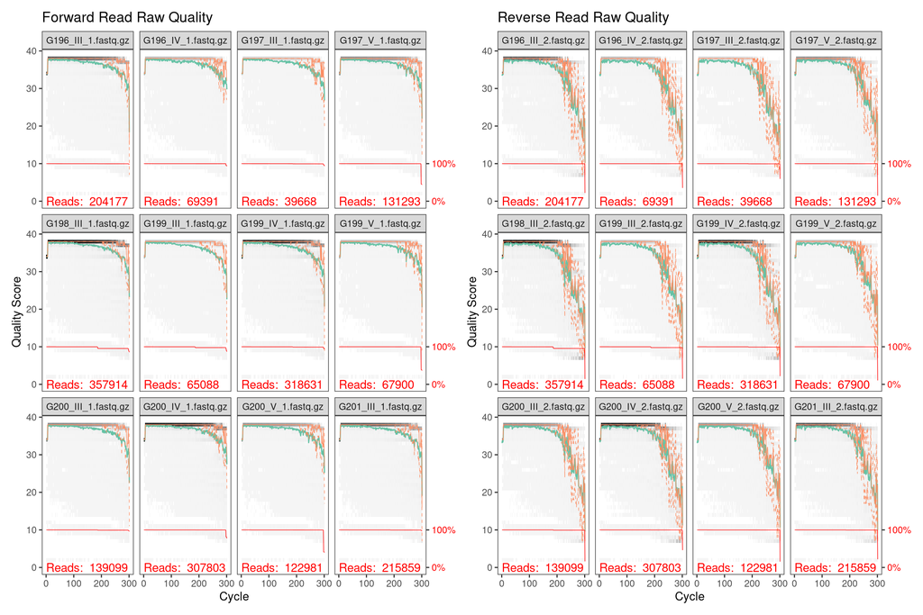

```r
# Calculate and plot quality of these two samples
forward_filteredQual_plot_14 <-
  plotQualityProfile(forward_reads[random_samples]) +
  labs(title = "Forward Read Raw Quality")

reverse_filteredQual_plot_14 <-
  plotQualityProfile(reverse_reads[random_samples]) +
  labs(title = "Reverse Read Raw Quality")


# Plot them together with patchwork
forward_filteredQual_plot_14 + reverse_filteredQual_plot_14
```

## Prepare a placeholder for filtered reads

```r
# vector of our samples, extract the sample information from our file
samples <-
  scan("/local/workdir/cab565/git_repos/Bikrim/data/00_cutadapt/Bikrim_samples.txt",
                what = "character")
#Intuition check
head(samples)
```

```
## [1] "G196_III" "G196_IV"  "G196_V"   "G197_III" "G197_IV"  "G197_V"
```

```r
#place filtered reads into filtered_fastqs_path
filtered_fastqs_path <- "data/01_DADA2/02_filtered_fastqs"
filtered_fastqs_path
```

```
## [1] "data/01_DADA2/02_filtered_fastqs"
```

```r
# create variable filtered_F
filtered_forward_reads <-
  file.path(filtered_fastqs_path, paste0(samples, "_R1_filtered.fastq.gz"))

# create variable filtered_R
filtered_reverse_reads <-
  file.path(filtered_fastqs_path, paste0(samples, "_R2_filtered.fastq.gz"))

#Intuition check
head(filtered_forward_reads)
```

```
## [1] "data/01_DADA2/02_filtered_fastqs/G196_III_R1_filtered.fastq.gz"
## [2] "data/01_DADA2/02_filtered_fastqs/G196_IV_R1_filtered.fastq.gz"
## [3] "data/01_DADA2/02_filtered_fastqs/G196_V_R1_filtered.fastq.gz"
## [4] "data/01_DADA2/02_filtered_fastqs/G197_III_R1_filtered.fastq.gz"
## [5] "data/01_DADA2/02_filtered_fastqs/G197_IV_R1_filtered.fastq.gz"
## [6] "data/01_DADA2/02_filtered_fastqs/G197_V_R1_filtered.fastq.gz"
```

```r
length(filtered_forward_reads)
```

```
## [1] 15
```

### Aggregated Raw Quality Plots

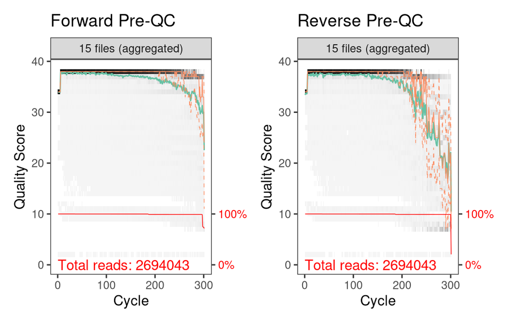

```r
# Aggregate all QC plots
# Forward reads
forward_preQC_plot <-
  plotQualityProfile(forward_reads, aggregate = TRUE) +
  labs(title = "Forward Pre-QC")

# reverse reads
reverse_preQC_plot <-
  plotQualityProfile(reverse_reads, aggregate = TRUE) +
  labs(title = "Reverse Pre-QC")

preQC_aggregate_plot <-
  # Plot the forward and reverse together
  forward_preQC_plot + reverse_preQC_plot

# Show the plot
preQC_aggregate_plot
```

## Filter and Trim Reads

Parameters of filter and trim **DEPEND ON THE DATASET**

- `maxN` = number of N bases. Remove all Ns from the data.
- `maxEE` = quality filtering threshold applied to expected errors. By default, all expected errors. Mar recommends using c(1,1). Here, if there is maxEE expected errors, its okay. If more, throw away sequence.
- `trimLeft` = trim certain number of base pairs on start of each read
- `truncQ` = truncate reads at the first instance of a quality score less than or equal to selected number. Chose 2
- `rm.phix` = remove phi x
- `compress` = make filtered files .gzipped
- `multithread` = multithread

```r
#Assign a vector to filtered reads
#Trim out poor bases, first three basepairs on forward reads
#Write out filtered fastq files
filtered_reads <-
  filterAndTrim(fwd = forward_reads, filt = filtered_forward_reads,
              rev = reverse_reads, filt.rev = filtered_reverse_reads,
              truncLen = c(275,275), trimLeft = c(50,55),
              maxN = 0, maxEE = c(1, 1),truncQ = 2, rm.phix = TRUE,
              compress = TRUE, multithread = 6)

# These files are described in Lee et al 2016
# Describes library prep
# Forward 5′ TCGTCGGCAG CGTCAGATGT GTATAAGAGA CAGCCTACGG GNGGCWGCAG 3′ (50)
# Reverse 5′ GTCTCGTGGG CTCGGAGATG TGTATAAGAG ACAGGACTAC HVGGGTATCT AATCC (55) 3′
```

### Trimmed Quality Plots

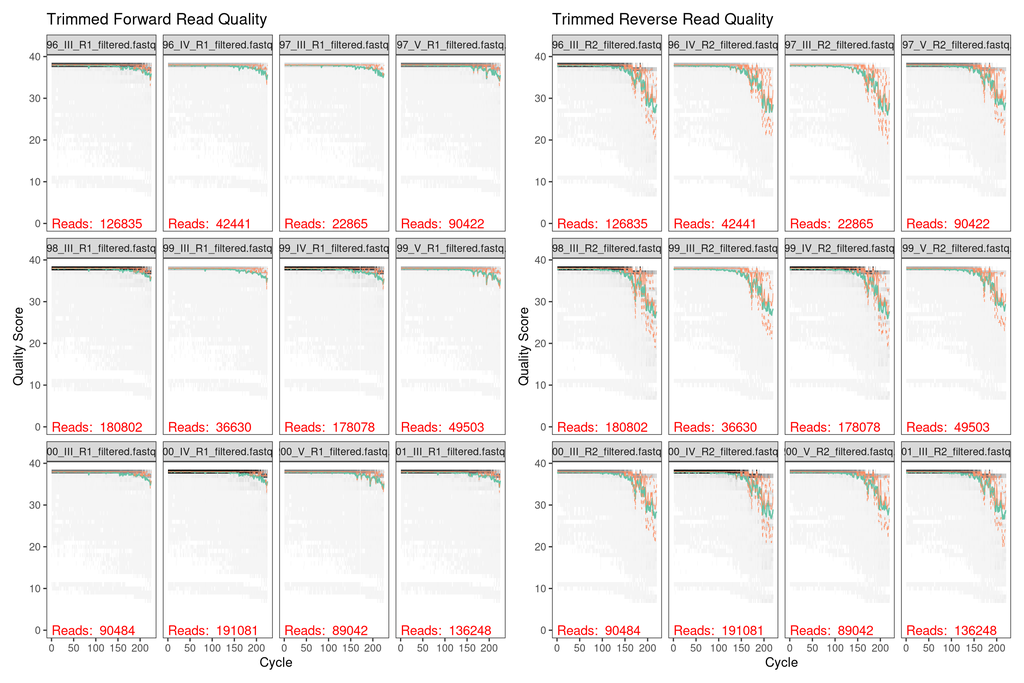

```r
# Plot the 12 random samples after QC
forward_filteredQual_plot_12 <-
  plotQualityProfile(filtered_forward_reads[random_samples]) +
  labs(title = "Trimmed Forward Read Quality")

reverse_filteredQual_plot_12 <-
  plotQualityProfile(filtered_reverse_reads[random_samples]) +
  labs(title = "Trimmed Reverse Read Quality")

# Put the two plots together
forward_filteredQual_plot_12 + reverse_filteredQual_plot_12
```

## Aggregated Trimmed Plots

```r
# Aggregate all QC plots
# Forward reads
forward_postQC_plot <-
  plotQualityProfile(filtered_forward_reads, aggregate = TRUE) +
  labs(title = "Forward Post-QC")

# reverse reads
reverse_postQC_plot <-
  plotQualityProfile(filtered_reverse_reads, aggregate = TRUE) +
  labs(title = "Reverse Post-QC")

postQC_aggregate_plot <-
  # Plot the forward and reverse together
  forward_postQC_plot + reverse_postQC_plot

# Show the plot
postQC_aggregate_plot
```

[output not shown]

## Stats on read output from `filterAndTrim`

```r
#Make output into dataframe
filtered_df <- as.data.frame(filtered_reads)
head(filtered_df)
```

```
##                     reads.in reads.out
## G196_III_1.fastq.gz   204177    126835
## G196_IV_1.fastq.gz     69391     42441
## G196_V_1.fastq.gz     394836    284139
## G197_III_1.fastq.gz    39668     22865
## G197_IV_1.fastq.gz     48641     28724
## G197_V_1.fastq.gz     131293     90422
```

```r
# calculate some stats
filtered_df %>%
  reframe(median_reads_in = median(reads.in),
          median_reads_out = median(reads.out),
          median_percent_retained = (median(reads.out)/median(reads.in)))
```

```
##   median_reads_in median_reads_out median_percent_retained
## 1          139099            90484               0.6505007
```

## Error Modeling

**Note every sequencing run needs to be run separately!** The error model *MUST* be run separately on each illumina dataset. If you’d like to combine the datasets from multiple sequencing runs, you’ll need to do the exact same `filterAndTrim()` step *AND*, very importantly, you’ll need to have the same primer and ASV length expected by the output.

Infer error rates for all possible transitions within purines and pyrimidines (A<>G or C<>T) and transversions between all purine and pyrimidine combinations.

Error model is learned by alternating estimation of the error rates and inference of sample composition until they converge.

1. Starts with the assumption that the error rates are the maximum (takes the most abundant sequence (“center”) and assumes it’s the only sequence not caused by errors).
2. Compares the other sequences to the most abundant sequence.
3. Uses at most 10<sup>8</sup> nucleotides for the error estimation.
4. Uses parametric error estimation function of loess fit on the observed error rates.

```r
#Forward reads
error_forward_reads <-
  learnErrors(filtered_forward_reads, multithread = 6)
```

```
## 102018375 total bases in 453415 reads from 3 samples will be used for learning the error rates.
```

```r
#Plot forward reads errors
forward_error_plot <-
  plotErrors(error_forward_reads, nominalQ = TRUE) +
  labs(title = "Forward Read Error Model")

#Reverse reads
error_reverse_reads <-
  learnErrors(filtered_reverse_reads, multithread = 6)
```

```
## 104781600 total bases in 476280 reads from 4 samples will be used for learning the error rates.
```

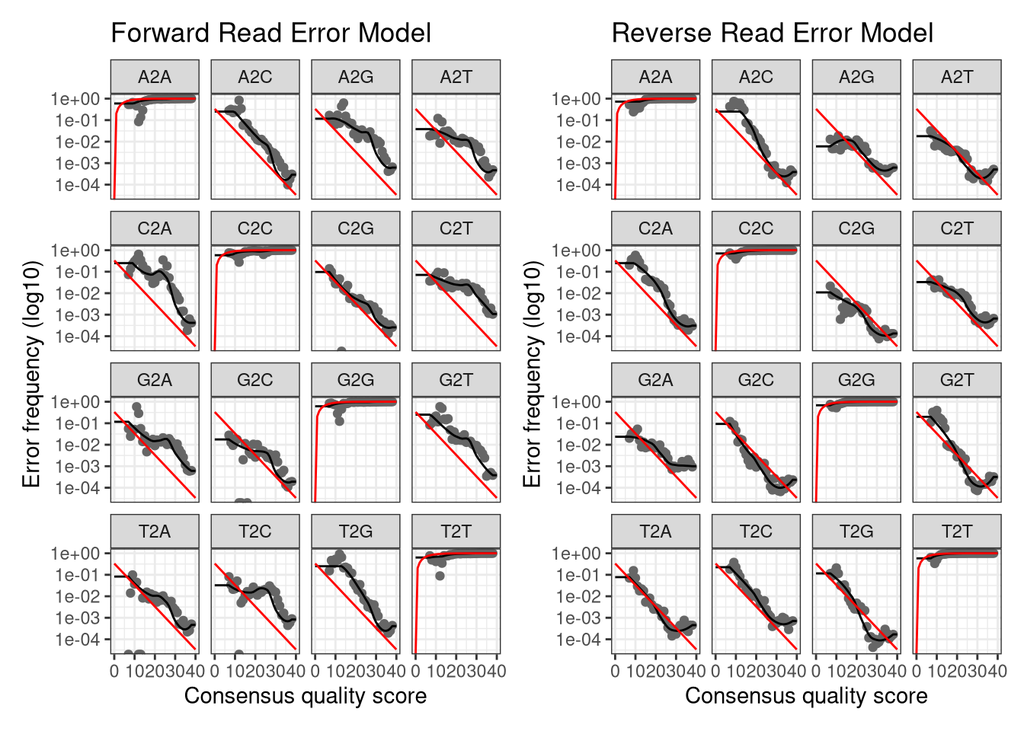

```r
#Plot reverse reads errors
reverse_error_plot <-
  plotErrors(error_reverse_reads, nominalQ = TRUE) +
    labs(title = "Reverse Read Error Model")

#Put the two plots together
forward_error_plot + reverse_error_plot
```

The error plots look pretty good. The points seem to follow the black lines.

- The error rates for each possible transition (A→C, A→G, …) are shown in the plot above.

Details of the plot: - **Points**: The observed error rates for each consensus quality score.  
- **Black line**: Estimated error rates after convergence of the machine-learning algorithm.  
- **Red line:** The error rates expected under the nominal definition of the Q-score.

Similar to what is mentioned in the dada2 tutorial: the estimated error rates (black line) are a “reasonably good” fit to the observed rates (points), and the error rates drop with increased quality as expected. We can now infer ASVs!

## Infer ASVs

**An important note:** This process occurs separately on forward and reverse reads! This is quite a different approach from how OTUs are identified in Mothur and also from UCHIME, oligotyping, and other OTU, MED, and ASV approaches.

```r
#Infer forward ASVs
dada_forward <- dada(filtered_forward_reads,
                     err = error_forward_reads,
                     multithread = 6)
```

```
## Sample 1 - 126835 reads in 12445 unique sequences.
## Sample 2 - 42441 reads in 3808 unique sequences.
## Sample 3 - 284139 reads in 33888 unique sequences.
## Sample 4 - 22865 reads in 2830 unique sequences.
## Sample 5 - 28724 reads in 3504 unique sequences.
## Sample 6 - 90422 reads in 12267 unique sequences.
## Sample 7 - 180802 reads in 16058 unique sequences.
## Sample 8 - 142207 reads in 15851 unique sequences.
## Sample 9 - 36630 reads in 5122 unique sequences.
## Sample 10 - 178078 reads in 17613 unique sequences.
## Sample 11 - 49503 reads in 7738 unique sequences.
## Sample 12 - 90484 reads in 9464 unique sequences.
## Sample 13 - 191081 reads in 15526 unique sequences.
## Sample 14 - 89042 reads in 11817 unique sequences.
## Sample 15 - 136248 reads in 12101 unique sequences.
```

```r
#Infer reverse ASVs
dada_reverse <- dada(filtered_reverse_reads,
                     err = error_reverse_reads,
                     multithread = 6)
```

```
## Sample 1 - 126835 reads in 15397 unique sequences.
## Sample 2 - 42441 reads in 4539 unique sequences.
## Sample 3 - 284139 reads in 34328 unique sequences.
## Sample 4 - 22865 reads in 3789 unique sequences.
## Sample 5 - 28724 reads in 4118 unique sequences.
## Sample 6 - 90422 reads in 13376 unique sequences.
## Sample 7 - 180802 reads in 24118 unique sequences.
## Sample 8 - 142207 reads in 18685 unique sequences.
## Sample 9 - 36630 reads in 7299 unique sequences.
## Sample 10 - 178078 reads in 21901 unique sequences.
## Sample 11 - 49503 reads in 8152 unique sequences.
## Sample 12 - 90484 reads in 12056 unique sequences.
## Sample 13 - 191081 reads in 19375 unique sequences.
## Sample 14 - 89042 reads in 12280 unique sequences.
## Sample 15 - 136248 reads in 16655 unique sequences.
```

```r
#Inspect
dada_forward[1]
```

```
## $G196_III_R1_filtered.fastq.gz
## dada-class: object describing DADA2 denoising results
## 376 sequence variants were inferred from 12445 input unique sequences.
## Key parameters: OMEGA_A = 1e-40, OMEGA_C = 1e-40, BAND_SIZE = 16
```

```r
dada_reverse[1]
```

```
## $G196_III_R2_filtered.fastq.gz
## dada-class: object describing DADA2 denoising results
## 285 sequence variants were inferred from 15397 input unique sequences.
## Key parameters: OMEGA_A = 1e-40, OMEGA_C = 1e-40, BAND_SIZE = 16
```

```r
dada_forward[12]
```

```
## $G200_III_R1_filtered.fastq.gz
## dada-class: object describing DADA2 denoising results
## 417 sequence variants were inferred from 9464 input unique sequences.
## Key parameters: OMEGA_A = 1e-40, OMEGA_C = 1e-40, BAND_SIZE = 16
```

```r
dada_reverse[12]
```

```
## $G200_III_R2_filtered.fastq.gz
## dada-class: object describing DADA2 denoising results
## 331 sequence variants were inferred from 12056 input unique sequences.
## Key parameters: OMEGA_A = 1e-40, OMEGA_C = 1e-40, BAND_SIZE = 16
```

# Merge Forward and Reverse ASVs

Now, merge the forward and reverse ASVs into contigs.

```r
# merge forward and reverse ASVs
merged_ASVs <- mergePairs(dada_forward, filtered_forward_reads,
                          dada_reverse, filtered_reverse_reads,
                          verbose = TRUE)
```

```
## 122849 paired-reads (in 617 unique pairings) successfully merged out of 125418 (in 1539 pairings) input.
```

```
## 41337 paired-reads (in 170 unique pairings) successfully merged out of 42065 (in 369 pairings) input.
```

```
## 267578 paired-reads (in 2829 unique pairings) successfully merged out of 280029 (in 8153 pairings) input.
```

```
## 22065 paired-reads (in 170 unique pairings) successfully merged out of 22380 (in 289 pairings) input.
```

```
## 27791 paired-reads (in 184 unique pairings) successfully merged out of 28299 (in 414 pairings) input.
```

```
## 85170 paired-reads (in 605 unique pairings) successfully merged out of 88998 (in 2333 pairings) input.
```

```
## 177439 paired-reads (in 755 unique pairings) successfully merged out of 179141 (in 1382 pairings) input.
```

```
## 136128 paired-reads (in 826 unique pairings) successfully merged out of 140088 (in 2670 pairings) input.
```

```
## 35678 paired-reads (in 434 unique pairings) successfully merged out of 36064 (in 581 pairings) input.
```

```
## 173565 paired-reads (in 782 unique pairings) successfully merged out of 176145 (in 1680 pairings) input.
```

```
## 46441 paired-reads (in 442 unique pairings) successfully merged out of 48538 (in 1483 pairings) input.
```

```
## 88019 paired-reads (in 470 unique pairings) successfully merged out of 89402 (in 925 pairings) input.
```

```
## 185812 paired-reads (in 771 unique pairings) successfully merged out of 189241 (in 2154 pairings) input.
```

```
## 84603 paired-reads (in 640 unique pairings) successfully merged out of 87539 (in 1921 pairings) input.
```

```
## 132800 paired-reads (in 567 unique pairings) successfully merged out of 134806 (in 1269 pairings) input.
```

```r
# Evaluate the output
typeof(merged_ASVs)
```

```
## [1] "list"
```

```r
length(merged_ASVs)
```

```
## [1] 15
```

```r
names(merged_ASVs)
```

```
##  [1] "G196_III_R1_filtered.fastq.gz" "G196_IV_R1_filtered.fastq.gz"
##  [3] "G196_V_R1_filtered.fastq.gz"   "G197_III_R1_filtered.fastq.gz"
##  [5] "G197_IV_R1_filtered.fastq.gz"  "G197_V_R1_filtered.fastq.gz"
##  [7] "G198_III_R1_filtered.fastq.gz" "G198_V_R1_filtered.fastq.gz"
##  [9] "G199_III_R1_filtered.fastq.gz" "G199_IV_R1_filtered.fastq.gz"
## [11] "G199_V_R1_filtered.fastq.gz"   "G200_III_R1_filtered.fastq.gz"
## [13] "G200_IV_R1_filtered.fastq.gz"  "G200_V_R1_filtered.fastq.gz"
## [15] "G201_III_R1_filtered.fastq.gz"
```

```r
# Inspect the merger data.frame from the 20210602-MA-ABB1P
head(merged_ASVs[[3]])
```

```
##                                                                                                                                                                                                                                                                                                          …
## 1 CCAGCCATGCCGCGTGCAGGATGACGGCTCTATGAGTTGTAAACTGCTTTTGTATGAGGG…
## 2 CCAGCCATGCCGCGTGCAGGATGACGGCTCTATGAGTTGTAAACTGCTTTTGTATGAGGG…
## 3 CCAGCCATGCCGCGTGCAGGATGACGGCTCTATGAGTTGTAAACTGCTTTTGTATGAGGG…
## 4 CCAGCCATGCCGCGTGCAGGATTAAGGCTCTATGAGTTGTAAACTGCTTTTGTAAGGGGG…
## 5 CCAGCCATGCCGCGTGCAGGATGACGGCTCTATGAGTTGTAAACTGCTTTTGTATGAGGG…
## 6 CCAGCCATGCCGCGTGCAGGATGACGGCTCTATGAGTTGTAAACTGCTTTTGTACGAGGG…
##   abundance forward reverse nmatch nmismatch nindel prefer accept
## 1     28913       1       1     90         0      0      2   TRUE
## 2     25558       2       3     90         0      0      1   TRUE
## 3     18678       3       2     90         0      0      2   TRUE
## 4      9990       4       4     90         0      0      2   TRUE
## 5      6082       5       6     90         0      0      2   TRUE
## 6      5774       6       7     90         0      0      1   TRUE
```

# Create Raw ASV Count Table

```r
# Create the ASV Count Table
raw_ASV_table <- makeSequenceTable(merged_ASVs)

# Write out the file to data/01_DADA2


# Check the type and dimensions of the data
dim(raw_ASV_table)
```

```
## [1]   15 5998
```

```r
class(raw_ASV_table)
```

```
## [1] "matrix" "array"
```

```r
typeof(raw_ASV_table)
```

```
## [1] "integer"
```

```r
# Inspect the distribution of sequence lengths of all ASVs in dataset
table(nchar(getSequences(raw_ASV_table)))
```

```
##
##  225  226  228  229  230  231  236  237  239  242  249  251  252  253  255  259
##    1    2    1    1    2    1    1    1    1    4    1    3   15    8    2    1
##  260  261  264  275  278  280  283  297  298  300  301  304  305  307  312  322
##    2    3    2    1    1    1    2    1    2    1    1    1    1    1    1    1
##  327  332  333  334  335  336  337  338  339  340  341  342  343  344  345  347
##    2    1    4  150  522  200  176  653   78  110    5   22    2    1   10    3
##  348  349  350  351  352  353  354  355  356  357  358  359  360  361  362  372
##    2   10    8    1    4    7  137 2815   34   17    4  302  587   46    6    1
##  382  390  404  408  417  424
##    1    1    1    6    1    1
```

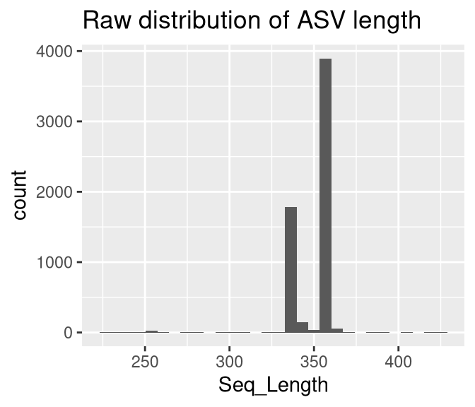

```r
# Inspect the distribution of sequence lengths of all ASVs in dataset
# AFTER TRIM
data.frame(Seq_Length = nchar(getSequences(raw_ASV_table))) %>%
  ggplot(aes(x = Seq_Length )) +
  geom_histogram() +
  labs(title = "Raw distribution of ASV length")
```

```r
###################################################
###################################################
# TRIM THE ASVS
# Let's trim the ASVs to only be the right size, which is 355.

# We will allow for a few
raw_ASV_table_trimmed <- raw_ASV_table[,nchar(colnames(raw_ASV_table)) %in% 355]

# Inspect the distribution of sequence lengths of all ASVs in dataset
table(nchar(getSequences(raw_ASV_table_trimmed)))
```

```
##
##  355
## 2815
```

```r
# What proportion is left of the sequences?
sum(raw_ASV_table_trimmed)/sum(raw_ASV_table)
```

```
## [1] 0.3447678
```

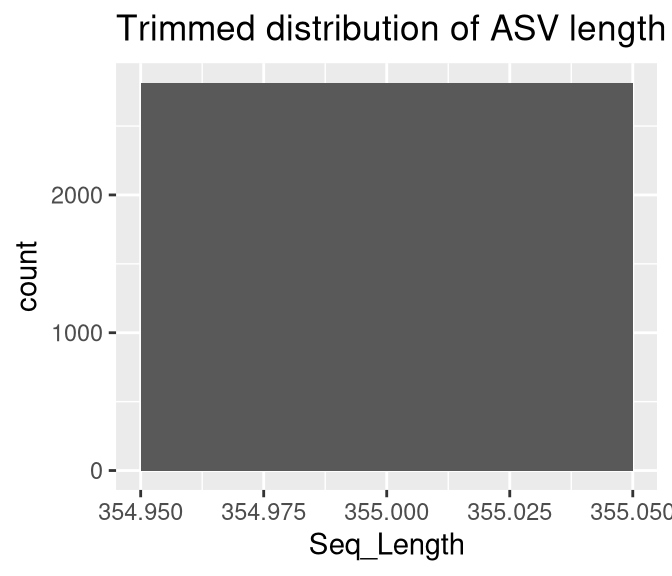

```r
# Inspect the distribution of sequence lengths of all ASVs in dataset
# AFTER TRIM
data.frame(Seq_Length = nchar(getSequences(raw_ASV_table_trimmed))) %>%
  ggplot(aes(x = Seq_Length )) +
  geom_histogram() +
  labs(title = "Trimmed distribution of ASV length")
```

# Remove Chimeras

Sometimes chimeras arise in our workflow.

**Chimeric sequences** are artificial sequences formed by the combination of two or more distinct biological sequences. These chimeric sequences can arise during the polymerase chain reaction (PCR) amplification step of the 16S rRNA gene, where fragments from different templates can be erroneously joined together.

Chimera removal is an essential step in the analysis of 16S sequencing data to improve the accuracy of downstream analyses, such as taxonomic assignment and diversity assessment. It helps to avoid the inclusion of misleading or spurious sequences that could lead to incorrect biological interpretations.

```r
# Remove the chimeras in the raw ASV table
noChimeras_ASV_table <- removeBimeraDenovo(raw_ASV_table_trimmed,
                                           method="consensus",
                                           multithread=6, verbose=TRUE)
```

```
## Identified 2559 bimeras out of 2815 input sequences.
```

```r
# Check the dimensions
dim(noChimeras_ASV_table)
```

```
## [1]  15 256
```

```r
# What proportion is left of the sequences?
sum(noChimeras_ASV_table)/sum(raw_ASV_table_trimmed)
```

```
## [1] 0.9143453
```

```r
sum(noChimeras_ASV_table)/sum(raw_ASV_table)
```

```
## [1] 0.3152368
```

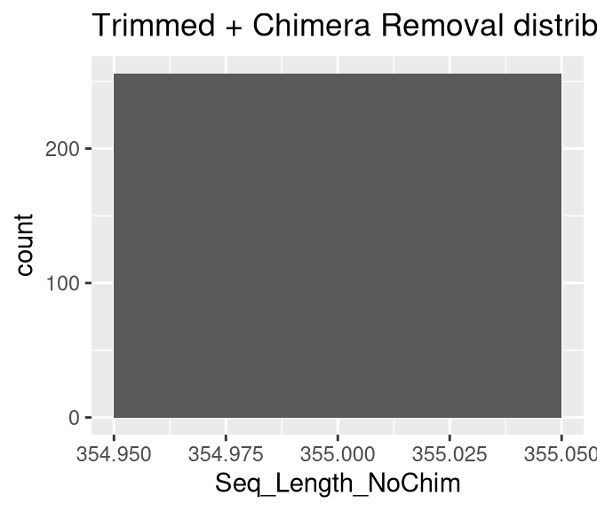

```r
# Plot it
data.frame(Seq_Length_NoChim = nchar(getSequences(noChimeras_ASV_table))) %>%
  ggplot(aes(x = Seq_Length_NoChim )) +
  geom_histogram()+
  labs(title = "Trimmed + Chimera Removal distribution of ASV length")
```

# Track the read counts

Here, we will look at the number of reads that were lost in the filtering, denoising, merging, and chimera removal.

```r
# A little function to identify number seqs
getN <- function(x) sum(getUniques(x))

# Make the table to track the seqs
track <- cbind(filtered_reads,
               sapply(dada_forward, getN),
               sapply(dada_reverse, getN),
               sapply(merged_ASVs, getN),
               rowSums(noChimeras_ASV_table))

head(track)
```

```
##                     reads.in reads.out
## G196_III_1.fastq.gz   204177    126835 125955 126131 122849    774
## G196_IV_1.fastq.gz     69391     42441  42195  42244  41337   2528
## G196_V_1.fastq.gz     394836    284139 281496 282479 267578 181231
## G197_III_1.fastq.gz    39668     22865  22502  22600  22065    745
## G197_IV_1.fastq.gz     48641     28724  28454  28530  27791   4961
## G197_V_1.fastq.gz     131293     90422  89396  89940  85170  58981
```

```r
# Update column names to be more informative (most are missing at the moment!)
colnames(track) <- c("input", "filtered", "denoisedF", "denoisedR", "merged", "nochim")
rownames(track) <- samples

# Generate a dataframe to track the reads through our DADA2 pipeline
track_counts_df <-
  track %>%
  # make it a dataframe
  as.data.frame() %>%
  rownames_to_column(var = "names") %>%
  mutate(perc_reads_retained = 100 * nochim / input)

# Visualize it in table format
DT::datatable(track_counts_df)
```

|  | names | input | filtered | denoisedF | denoisedR | merged | nochim | perc_reads_retained |
| --- | --- | --- | --- | --- | --- | --- | --- | --- |
| 1 | G196_III | 204177 | 126835 | 125955 | 126131 | 122849 | 774 | 0.3790828545820538 |
| 2 | G196_IV | 69391 | 42441 | 42195 | 42244 | 41337 | 2528 | 3.643123748036489 |
| 3 | G196_V | 394836 | 284139 | 281496 | 282479 | 267578 | 181231 | 45.90032317215249 |
| 4 | G197_III | 39668 | 22865 | 22502 | 22600 | 22065 | 745 | 1.878088131491378 |
| 5 | G197_IV | 48641 | 28724 | 28454 | 28530 | 27791 | 4961 | 10.19921465430398 |
| 6 | G197_V | 131293 | 90422 | 89396 | 89940 | 85170 | 58981 | 44.92318707014083 |
| 7 | G198_III | 357914 | 180802 | 179706 | 180164 | 177439 | 8503 | 2.37571036617735 |
| 8 | G198_V | 210762 | 142207 | 140741 | 141377 | 136128 | 101967 | 48.38016340706579 |
| 9 | G199_III | 65088 | 36630 | 36257 | 36361 | 35678 | 1477 | 2.269235496558506 |
| 10 | G199_IV | 318631 | 178078 | 176867 | 177194 | 173565 | 7545 | 2.367942855528809 |

[output cut: 5 more lines]

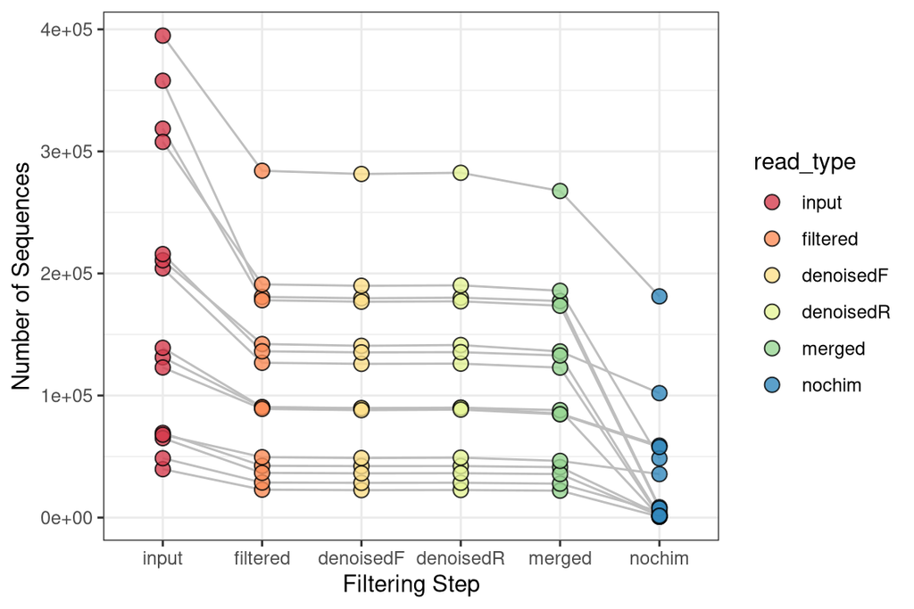

```r
# Plot it!
track_counts_df %>%
  pivot_longer(input:nochim, names_to = "read_type", values_to = "num_reads") %>%
  mutate(read_type = fct_relevel(read_type,
                                 "input", "filtered", "denoisedF", "denoisedR", "merged", "nochim")) %>%
  ggplot(aes(x = read_type, y = num_reads, fill = read_type)) +
  geom_line(aes(group = names), color = "grey") +
  geom_point(shape = 21, size = 3, alpha = 0.8) +
  scale_fill_brewer(palette = "Spectral") +
  labs(x = "Filtering Step", y = "Number of Sequences") +
  theme_bw()
```

# We are not assigning taxonomy at this point. We will assign taxonomy after we merge this dataset with the other datasets in our meta-analysis.

# Prepare the data for export!

## 1. ASV Table

### Finalize ASV Count Tables

```r
########### 2. COUNT TABLE ###############
############## Modify the ASV names and then save a fasta file!  ##############
# Give headers more manageable names
# First pull the ASV sequences
asv_seqs <- colnames(noChimeras_ASV_table)
asv_seqs[1:5]
```

```
## [1] "CCAGCCATGCCGCGTGCAGGATGACGGCTCTATGAGTTGTAAACTGCTTTTGTATGAGGG…"
## [2] "CCAGCCATGCCGCGTGCAGGATGACGGCTCTATGAGTTGTAAACTGCTTTTGTATGAGGG…"
## [3] "CCAGCCATGCCGCGTGCAGGATGACGGCTCTATGAGTTGTAAACTGCTTTTGTATGAGGG…"
## [4] "CCAGCCATGCCGCGTGCAGGATGACGGCTCTATGAGTTGTAAACTGCTTTTGTACGAGGG…"
## [5] "CCAGCCATGCCGCGTGCAGGATGACGGCTCTATGAGTTGTAAACTGCTTTTGTATGAGGG…"
```

```r
# make headers for our ASV seq fasta file, which will be our asv names
asv_headers <- vector(dim(noChimeras_ASV_table)[2], mode = "character")
asv_headers[1:5]
```

```
## [1] "" "" "" "" ""
```

```r
# loop through vector and fill it in with ASV names
for (i in 1:dim(noChimeras_ASV_table)[2]) {
  asv_headers[i] <- paste(">ASV", i, sep = "_")
}

# intitution check
asv_headers[1:5]
```

```
## [1] ">ASV_1" ">ASV_2" ">ASV_3" ">ASV_4" ">ASV_5"
```

```r
##### Rename ASVs in table then write out our ASV fasta file!
#View(noChimeras_ASV_table)
asv_tab <- t(noChimeras_ASV_table)
#View(asv_tab)

## Rename our asvs!
row.names(asv_tab) <- sub(">", "", asv_headers)
#View(asv_tab)
```

# Write `01_DADA2` files

```r
# FIRST, we will save our output as regular files, which will be useful later on.
# Save to regular .tsv file
# Write BOTH the modified and unmodified ASV tables to a file!
# Write count table with ASV numbered names (e.g. ASV_1, ASV_2, etc)
write.table(asv_tab, "data/01_DADA2/Bikrim_analysis/ASV_counts.tsv",
            sep = "\t", quote = FALSE, col.names = NA)
# Write count table with ASV sequence names
write.table(noChimeras_ASV_table,
            "data/01_DADA2/Bikrim_analysis/ASV_counts_withSeqNames.tsv",
            sep = "\t", quote = FALSE, col.names = NA)
# Write out the fasta file for reference later on for what seq matches what ASV
asv_fasta <- c(rbind(asv_headers, asv_seqs))
# Save to a file!
write(asv_fasta, "data/01_DADA2/Bikrim_analysis/ASVs.fasta")

# SECOND, let's save to a RData object
# Each of these files will be used in the analysis/02_PreProcessing
# RData objects are for easy loading :)
save(noChimeras_ASV_table,
     file = "data/01_DADA2/Bikrim_analysis/noChimeras_ASV_table.RData")
save(asv_tab, file = "data/01_DADA2/Bikrim_analysis/ASV_counts.RData")
# And save the track_counts_df a R object, which we will merge with metadata information in the next step of the analysis in analysis/02_PreProcessing.
save(track_counts_df, file = "data/01_DADA2/Bikrim_analysis/track_read_counts.RData")
```